# Global Insights into Child Mortality

Muskan Miglani  
April 26, 2025

**Program Name:** Masters in Management (Strategy)  
**Course:** Spring 2025 - BAA1030 Data Analytics & Storytelling  
**Student:** Muskan Miglani (A00011008)

# Introduction

Child mortality is among the most significant indicators of a country’s healthcare, and development overall.

This report presents different techniques in data analytics for visualising global child mortality trends.

Specifically, we wish to answer a series of important questions:

- Where are the global areas of very high child mortality?
- How healthcare infrastructure is associated with child mortality?
- Is there a relationship between GDP per capita and child mortality?

To show that child mortality inequalities require urgent attention globally, we provide maps, bar charts, scatterplots, line charts and pie charts.

# 1. Child Mortality Hotspots

> Where are the global hotspots for child mortality?

In this visualization the number of child deaths in total per country is displayed as a global map.  
Darker shades indicate higher child deaths. Countries such as Nigeria and India are dark in color,  
signifying where the greatest need of interventions occurred.  
Gray areas are missing data.

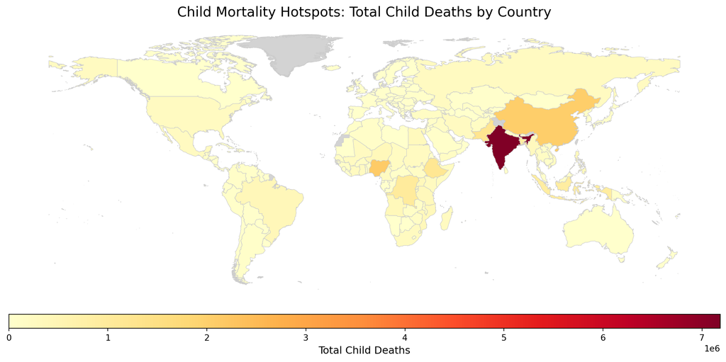

```python
import matplotlib.pyplot as plt
from mpl_toolkits.axes_grid1 import make_axes_locatable
import geopandas as gpd
import polars as pl
import pandas as pd
from plotnine import *
import ipywidgets as widgets
from IPython.display import display
import random


world = gpd.read_file("https://public.opendatasoft.com/api/explore/v2.1/catalog/datasets/world-administrative-boundaries/exports/shp")
tableau_data = pl.read_csv("/content/child_mortality_cleaned.csv")

df = (
    tableau_data
    .group_by("country_code")
    .agg(pl.col("child_deaths").sum().alias("total_deaths"))
    .to_pandas()
)

merged = world.merge(df, how="left", left_on="iso3", right_on="country_code")

fig, ax = plt.subplots(1, 1, figsize=(15, 8))
divider = make_axes_locatable(ax)
cax = divider.append_axes("bottom", size="5%", pad=0.2)

plot = merged.plot(
    column="total_deaths",
    cmap="YlOrRd",
    linewidth=0.5,
    ax=ax,
    edgecolor="0.8",
    legend=False,
    missing_kwds={"color": "lightgrey", "label": "No data"}
)

sm = plt.cm.ScalarMappable(cmap="YlOrRd", norm=plt.Normalize(vmin=merged["total_deaths"].min(), vmax=merged["total_deaths"].max()))
sm._A = []

cbar = fig.colorbar(sm, cax=cax, orientation="horizontal", shrink=1)
cbar.set_label("Total Child Deaths", fontsize=12)

ax.set_title("Child Mortality Hotspots: Total Child Deaths by Country", fontsize=16)
ax.axis("off")

plt.show()
```